# 대한민국 제21대 국회의원 선거

## 2.2 종부세와 근로세

```r
tax_category_df <- tax_df %>%
  mutate(세목 = case_when(구분 %in% c("상속세", "증여세", "종합부동산세", "양도소득세") ~ "재산소득",
                            구분 %in% c("이자소득세", "배당소득세") ~ "금융소득",
                            구분 %in% c("종합소득세", "사업소득세") ~ "자영업자",
                            구분 %in% c("근로소득세") ~ "급여사업자",
                            TRUE ~ 구분)) %>%
  mutate(세목 = ifelse(구분 == "종합부동산세", "종합부동산세", 세목)) %>%
  mutate(수납액 = `수납액`/10^6) %>%
  select(연도, 세목, 수납액) %>%
  filter(세목 %in% c("급여사업자", "금융소득", "재산소득", "종합부동산세", "자영업자")) %>%
  group_by(세목, 연도) %>%
  dplyr::summarise(수납액 = sum(수납액)) %>%
  ungroup() %>%
  mutate(세목 = factor(세목, levels = c("급여사업자", "자영업자", "종합부동산세", "금융소득", "재산소득")))

tax_category_df %>%
  spread(연도, 수납액) %>%
  DT::datatable() %>%
  DT::formatRound(2:13, digits=1)
```

|  | 세목 | 2009 | 2010 | 2011 | 2012 | 2013 | 2014 | 2015 | 2016 | 2017 | 2018 | 2019 | 2020 |
| --- | --- | --- | --- | --- | --- | --- | --- | --- | --- | --- | --- | --- | --- |
| 1 | 급여사업자 | 15.595142 | 13.40688 | 15.516911 | 18.337339 | 19.627025 | 22.494398 | 26.135601 | 28.109488 | 31.974012 | 35.067567 | 39.054569 | 41.971242 |
| 2 | 자영업자 | 5.421144 | 7.517781 | 7.878822 | 9.951814 | 11.682772 | 12.699649 | 13.407047 | 15.555954 | 17.383888 | 19.415696 | 21.134049 | 22.057984 |
| 3 | 종합부동산세 | 2.129862 | 1.207101 | 1.028932 | 1.101864 | 1.131106 | 1.224321 | 1.307211 | 1.399035 | 1.293892 | 1.651974 | 1.872762 | 2.671265 |
| 4 | 금융소득 | 4.659011 | 4.76168 | 4.425077 | 4.895611 | 5.151821 | 4.888616 | 4.627917 | 4.560824 | 4.124674 | 4.516901 | 4.981992 | 5.576711 |
| 5 | 재산소득 | 12.102121 | 9.738261 | 11.239422 | 10.722054 | 11.475685 | 10.946885 | 12.672677 | 16.899716 | 19.033341 | 21.918815 | 25.381588 | 24.430294 |

## 2.3 시각화

다음 4가지 범주로 시각화한다.

- 급여사업자를 대표하는 근로소득세
- 자영업자대 대표하는 종합소득세, 사업소득세
- 부동산을 대표하는 종합부동산세
- 금융을 대표하는 이자소득세와 배당소득세

### 2.3.1 정적 시각화

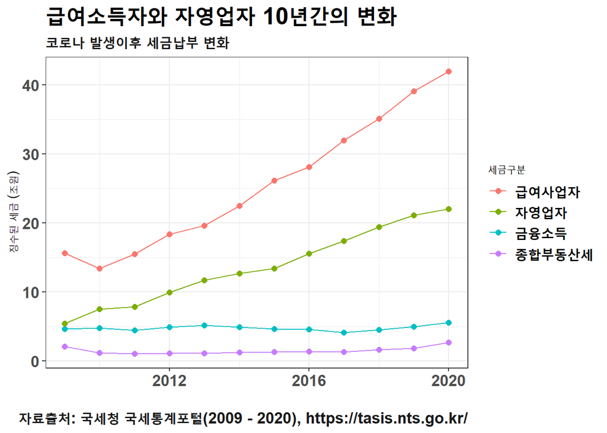

```r
library(gghighlight)
extrafont::loadfonts()

tax_category_df %>%
  filter(세목 != "재산소득") %>%
  mutate(세목 = factor(세목, levels = c("급여사업자", "자영업자", "금융소득", "종합부동산세"))) %>%
  ggplot(aes(x=연도, y=수납액, group=세목, color=세목)) +
    geom_point(size = 2) +
    geom_line() +
    # gghighlight(max(연도) >= 2020,  use_direct_label = FALSE) +
    theme_bw(base_family = "NanumGothic") +
    labs(x="", y ="징수된 세금 (조원)",
         title   ="급여소득자와 자영업자 10년간의 변화",
         caption ="자료출처: 국세청 국세통계포털(2009 - 2020), https://tasis.nts.go.kr/",
         subtitle = "코로나 발생이후 세금납부 변화",
         color  = "세금구분") +
    theme(legend.position = "right",
          legend.text = element_text(size = 13, colour = "black", family = "NanumBarunpen", face="bold"),
          strip.text.x = element_text(size = 15, colour = "black", family = "NanumMyeongjo", face="bold"),
          strip.background=element_rect(fill="gray95"),
          axis.text.x = element_text(face="bold", size=13, angle=0),
          axis.text.y = element_text(face="bold", size=13, angle=0),
          plot.title=element_text(size=20, face="bold", family = "NanumBarunpen"),
          plot.caption = element_text(face="bold", size=13, colour="grey10", family = "NanumBarunpen"),
          plot.subtitle=element_text(face="bold", size=13, colour="grey10", family = "NanumBarunpen"))
```

### 2.3.2 인터랙티브 시각화

```r
library(dygraphs)
library(xts)

tax_category_wide_df <- tax_category_df %>%
  filter(세목 != "재산소득") %>%
  spread(세목, 수납액) %>%
  mutate(연도 = lubridate::make_date(year=연도, month=7, day=1))

tax_category_xts <- xts(tax_category_wide_df[,-1], order.by = tax_category_wide_df$연도)

dygraph(tax_category_xts, main="급여소득자와 자영업자 10년간의 변화",
        y="징수된 세금 (조원)") %>%
  dyOptions(drawPoints = TRUE, pointSize = 2) %>%
  dyHighlight(highlightSeriesOpts = list(strokeWidth = 3)) %>%
  dyLegend(width = 600)
```

[interactive chart not shown]

[^1]: [최훈길 기자 (2019-12-03), “직장인 지갑만 털었다…근로소득세 10년새 2.5배”, 이데일리](https://www.edaily.co.kr/news/read?newsId=01377606622714912&mediaCodeNo=257)
[^2]: [국세청 → 국세통계 → 통계자료실](https://stats.nts.go.kr/data/data.asp)
[^3]: [조세플러스 (2018-07-27), “우리나라, 재산관련 세수 49조-총세수의 12%…OECD 2위”](http://www.joseplus.com/news/newsview.php?ncode=1065573608259799)